# convert

```python
#Import necessary libraries
import nibabel as nib
import matplotlib.pyplot as plt
import numpy as np
import cv2
```

```python
scan = nib.load('sub-HC001_ses-01_acq-mp2rage_T1map.nii.gz') # CONP PCNO data instance
scanArray = scan.get_fdata()
```

```python
scan.dataobj
```

```
<nibabel.arrayproxy.ArrayProxy at 0x227a693fc20>
```

here the image stored in a disk is accessed through a proxy get_fdata() method fetches the image data array through the proxy whebn we request.

```python
scan.shape
```

```
(240, 320, 320)
```

```python
scan.get_data_dtype() == np.dtype('float32')
```

```
True
```

so the data is on float 32 data type

nibabel image consists 3 things

- image data array
- affine array which tells the relative position from referrence
- image header - metadata

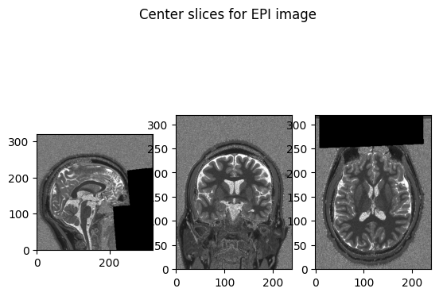

```python
def show_slices(slices):
   """ Function to display row of image slices """
   fig, axes = plt.subplots(1, len(slices))
   for i, slice in enumerate(slices):
       axes[i].imshow(slice.T, cmap="gray", origin="lower")

shape = scan.shape
slice_0 = scanArray[shape[0]//2, :, :]
slice_1 = scanArray[:, shape[1]//2, :]
slice_2 = scanArray[:, :, shape[2]//2]
show_slices([slice_0, slice_1, slice_2])
plt.suptitle("Center slices for EPI image")
```

EPI scan vs anatomical scan

- epi used to measure brain activity by detecting changes associated with the blood flow, fast and low spatial resolution
- anatomical scan captures detailed high res brain structure to examine brain anatomy. slow but hi snr

As y’all know, a voxel is a pixel with volume.

The 3D array is therefore also a voxel array.

```python
scanArray.shape
```

```
(240, 320, 320)
```

```python
i,j,k = scanArray.shape
center_i = i // 2
center_j = j // 2
center_k = k // 2
center_voxel = scanArray[center_i, center_j, center_k]
center_voxel
```

```
1331.0
```

voxel coordinates in the EPI image refer to different locations in the magnet to the voxel coordinates in the anatomical image.

We solve this problem by **keeping track of the relationship of voxel coordinates to some reference space**. In particular, the **affine array** stores the relationship between voxel coordinates in the image data array and coordinates in the reference space.

**The scanner axes**

- The origin of the axes is at the magnet isocenter. This is coordinate (0, 0, 0) in our reference space. All three axes pass through the isocenter.
- The units for all three axes are **millimeters**.
- Imagine an observer standing behind the scanner looking through the magnet bore towards the end of the scanner bed. Imagine a **line traveling towards the observer through the center of the magnet bore, parallel to the bed, with the zero point at the magnet isocenter, and positive values closer to the observer**. Call this line the scanner-bore axis.
- Draw a line traveling **from the scanner room floor up through the magnet isocenter towards the ceiling, at right angles to the scanner bore axis. 0 is at isocenter and positive values are towards the ceiling**. Call this the scanner-floor/ceiling axis.
- Draw a line at right angles to the other two lines, traveling **from the observer’s left, parallel to the floor, and through the magnet isocenter to the observer’s right**. 0 is at isocenter and positive values are to the right. Call this the scanner-left/right.
- (X, Y, Z) = (Scanner left-right, Scanner floor-ceil, Scanner bore)

If the subject is lying in the usual position for a brain scan, face up and head first in the scanner, then scanner-left/right is also the left-right axis of the subject’s head, scanner-floor/ceiling is the posterior-anterior axis of the head and scanner-bore is the inferior-superior axis of the head.

[figure not shown]

The most common subject-centered scanner coordinate system in neuroimaging is called “scanner RAS” (right, anterior, superior).

“RAS+”, meaning that Right, Anterior, Superior are all positive values on these axes

```python
print(nib.orientations.aff2axcodes(scan.affine))
print(scan.affine)
las = scan.slicer[::-1]
print(nib.orientations.aff2axcodes(las.affine))
print(las.affine)
```

```
('R', 'A', 'S')
[[   0.8     0.03   -0.02  -92.06]
 [  -0.03    0.79    0.11 -107.89]
 [   0.03   -0.11    0.79 -116.85]
 [   0.      0.      0.      1.  ]]
('L', 'A', 'S')
[[  -0.8     0.03   -0.02  -92.06]
 [   0.03    0.79    0.11 -107.89]
 [  -0.03   -0.11    0.79 -116.85]
 [   0.      0.      0.      1.  ]]
```

since **RAS+** is the canonical orientation in nibabel, to rearrange any image voxel axes to make them as close as possible to RAS+ we can use the below function

```python
canonical = nib.as_closest_canonical(las)
print(nib.orientations.aff2axcodes(canonical.affine))
print(canonical.affine)
```

```
('R', 'A', 'S')
[[   0.8     0.03   -0.02 -283.02]
 [  -0.03    0.79    0.11 -100.9 ]
 [   0.03   -0.11    0.79 -123.3 ]
 [   0.      0.      0.      1.  ]]
```

but voxel coordinates are also in a space. In this case the space is defined by the three voxel axes (first axis, second axis, third axis), where 0, 0, 0 is the center of the first voxel in the array and the units on the axes are voxels. Voxel coordinates are therefore defined in a reference space called voxel space.

```python
#Get and print the scan's shape
scanArrayShape = scanArray.shape
print('The scan data array has the shape: ', scanArrayShape)
```

```
The scan data array has the shape:  (240, 320, 320)
```

affine array is a 4x4 matrix which combines zooming, rotating, and translation

```python
print(scan.affine.shape)
print(scan.affine)
```

```
(4, 4)
[[ 7.99010114e-01  3.26465886e-02 -2.27388862e-02 -9.20572433e+01]
 [-2.92277461e-02  7.91877189e-01  1.09892105e-01 -1.07888611e+02]
 [ 2.69925091e-02 -1.08925370e-01  7.92090075e-01 -1.16848816e+02]
 [ 0.00000000e+00  0.00000000e+00  0.00000000e+00  1.00000000e+00]]
```

```python
np.set_printoptions(precision=2, suppress=True) # to print only 2decimals for neatness
print(scan.affine)
```

```
[[   0.8     0.03   -0.02  -92.06]
 [  -0.03    0.79    0.11 -107.89]
 [   0.03   -0.11    0.79 -116.85]
 [   0.      0.      0.      1.  ]]
```

applying affine

```python
M = scan.affine[:3, :3]
abc = scan.affine[:3, 3]
```

```python
def get_voxel_coordinates(i, j, k, M, abc):
    return M.dot([i, j, k]) + abc
```

```python
physical_center = get_voxel_coordinates(center_i, center_j, center_k, M, abc)
print(physical_center)
```

```
[ 5.41 32.89 -4.3 ]
```

```python
# built in apply affine function

nib.affines.apply_affine(scan.affine, [center_i, center_j, center_k])
```

```
array([ 5.41, 32.89, -4.3 ])
```

nifti 2 will use 64bit

```python
#Examine scan's shape and header
scanHeader = scan.header
print('The scan header is as follows: \n', scanHeader)
```

```
The scan header is as follows:
 <class 'nibabel.nifti1.Nifti1Header'> object, endian='<'
sizeof_hdr      : 348
data_type       : b''
db_name         : b''
extents         : 0
session_error   : 0
regular         : b'r'
dim_info        : 0
dim             : [  3 240 320 320   1   1   1   1]
intent_p1       : 0.0
intent_p2       : 0.0
intent_p3       : 0.0
intent_code     : none
datatype        : float32
bitpix          : 32
slice_start     : 0
pixdim          : [1.  0.8 0.8 0.8 0.  0.  0.  0. ]
vox_offset      : 0.0
scl_slope       : nan
scl_inter       : nan
slice_end       : 0
slice_code      : unknown
xyzt_units      : 10
cal_max         : 0.0
cal_min         : 0.0
slice_duration  : 0.0
toffset         : 0.0
glmax           : 0
glmin           : 0
descrip         : b'6.0.0'
aux_file        : b''
qform_code      : scanner
sform_code      : unknown
quatern_b       : -0.06856307
quatern_c       : -0.015582562
quatern_d       : -0.019387364
qoffset_x       : -92.05724
qoffset_y       : -107.88861
qoffset_z       : -116.848816
srow_x          : [0. 0. 0. 0.]
srow_y          : [0. 0. 0. 0.]
srow_z          : [0. 0. 0. 0.]
intent_name     : b''
magic           : b'n+1'
```

```python
scanHeader.get_xyzt_units()
```

```
('mm', 'sec')
```

to get voxel sizes in millimetres

```python
scanHeader.get_zooms()
```

```
(0.8, 0.8, 0.8)
```

**qfac** (sign flip) is pixdim[0]

to get a,b,c,d quartenions

```python
scanHeader.get_qform_quaternion()
```

```
array([ 1.  , -0.07, -0.02, -0.02])
```

```python
scanHeader.get_qform()
```

```
array([[   0.8 ,    0.03,   -0.02,  -92.06],
       [  -0.03,    0.79,    0.11, -107.89],
       [   0.03,   -0.11,    0.79, -116.85],
       [   0.  ,    0.  ,    0.  ,    1.  ]])
```

```python
print(scanHeader['sform_code'])
```

```
0
```

```python
scanHeader.get_sform()
```

```
array([[0., 0., 0., 0.],
       [0., 0., 0., 0.],
       [0., 0., 0., 0.],
       [0., 0., 0., 1.]])
```

sform_code list

[figure not shown]

**fall-back header affine** is constructed only from the pixdim voxel slices.

```python
scanHeader.get_base_affine()
```

```
array([[  -0.8,    0. ,    0. ,   95.6],
       [   0. ,    0.8,    0. , -127.6],
       [   0. ,    0. ,    0.8, -127.6],
       [   0. ,    0. ,    0. ,    1. ]])
```

Given there are three possible affines defined in the NIfTI header, nibabel has to chose which of these to use for the image affine.

The algorithm is defined in the get_best_affine() method. It is:

- If sform_code != 0 (‘unknown’) use the sform affine; else
- If qform_code != 0 (‘unknown’) use the qform affine; else
- Use the fall-back affine.

best affine :

```python
print(scanHeader.get_best_affine() == scanHeader.get_sform())
print(scanHeader.get_best_affine() == scanHeader.get_qform())
print(scanHeader.get_best_affine() == scanHeader.get_base_affine())
```

```
[[False False False False]
 [False False False False]
 [False False False False]
 [ True  True  True  True]]
[[ True  True  True  True]
 [ True  True  True  True]
 [ True  True  True  True]
 [ True  True  True  True]]
[[False False False False]
 [False False False False]
 [False False False False]
 [ True  True  True  True]]
```

```python
scan.affine
```

```
array([[   0.8 ,    0.03,   -0.02,  -92.06],
       [  -0.03,    0.79,    0.11, -107.89],
       [   0.03,   -0.11,    0.79, -116.85],
       [   0.  ,    0.  ,    0.  ,    1.  ]])
```

to get header in array format

```python
scanHeader.structarr
```

```
array((348, b'', b'', 0, 0, b'r', 0, [  3, 240, 320, 320,   1,   1,   1,   1], 0., 0., 0., 0, 16, 32, 0, [1. , 0.8, 0.8, 0.8, 0. , 0. , 0. , 0. ], 0., nan, nan, 0, 0, 10, 0., 0., 0., 0., 0, 0, b'6.0.0', b'', 1, 0, -0.07, -0.02, -0.02, -92.06, -107.89, -116.85, [0., 0., 0., 0.], [0., 0., 0., 0.], [0.…
      dtype=[('sizeof_hdr', '<i4'), ('data_type', 'S10'), ('db_name', 'S18'), ('extents', '<i4'), ('session_error', '<i2'), ('regular', 'S1'), ('dim_info', 'u1'), ('dim', '<i2', (8,)), ('intent_p1', '<f4'), ('intent_p2', '<f4'), ('intent_p3', '<f4'), ('intent_code', '<i2'), ('datatype', '<i2'), ('bi…
```

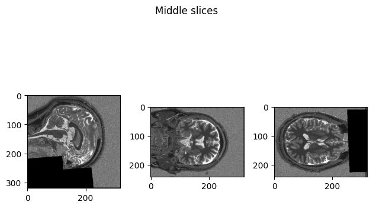

```python
#Display scan array's middle slices
fig, axs = plt.subplots(1,3)
# fig.suptitle('Scan Array (Middle Slices)')
axs[0].imshow(scanArray[scanArrayShape[0]//2,:,:], cmap='gray')
axs[1].imshow(scanArray[:,scanArrayShape[1]//2,:], cmap='gray')
axs[2].imshow(scanArray[:,:,scanArrayShape[2]//2], cmap='gray')
fig.tight_layout()
fig.suptitle("Middle slices")
plt.show()
```

```python
#Calculate proper aspect ratios
pixDim = scanHeader['pixdim'][1:4]
aspectRatios = [pixDim[1]/pixDim[2],pixDim[0]/pixDim[2],pixDim[0]/pixDim[1]]
print('The required aspect ratios are: ', aspectRatios)
```

```
The required aspect ratios are:  [1.0, 1.0, 1.0]
```

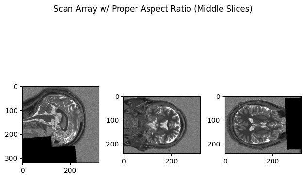

```python
#Display scan array's middle slices with proper aspect ratio
fig, axs = plt.subplots(1,3)
fig.suptitle('Scan Array w/ Proper Aspect Ratio (Middle Slices)')
axs[0].imshow(scanArray[scanArrayShape[0]//2,:,:], aspect = aspectRatios[0], cmap='gray')
axs[1].imshow(scanArray[:,scanArrayShape[1]//2,:], aspect = aspectRatios[1], cmap='gray')
axs[2].imshow(scanArray[:,:,scanArrayShape[2]//2], aspect = aspectRatios[2], cmap='gray')
fig.tight_layout()
plt.show()
```

```python
#Calculate new image dimensions from aspect ratio
newScanDims = np.multiply(scanArrayShape, pixDim)
newScanDims = (round(newScanDims[0]),round(newScanDims[1]),round(newScanDims[2]))
print('The new scan dimensions are: ', newScanDims)
```

```
The new scan dimensions are:  (192, 256, 256)
```

scl_slope and scl_inter in header will be used to scale the image data array when loading the data, if both of the are not NaN

```python
# #Set the output file path
# outputPath = 'StanfordData Set'

# #Iterate and save scan slices along 0th dimension
# for i in range(scanArrayShape[0]):
#     #Resample the slice
#     outputArray = cv2.resize(scanArray[i,:,:], (newScanDims[2],newScanDims[1]))
#     #Save the slice as .png image
#     cv2.imwrite(outputPath+'/Dim0_Slice'+str(i)+'.png', outputArray)

# #Iterate and save scan slices along 1st dimension
# for i in range(scanArrayShape[1]):
#     #Resample the slice
#     outputArray = cv2.resize(scanArray[:,i,:], (newScanDims[2],newScanDims[0]))
#     #Save the slice as .png image
#     cv2.imwrite(outputPath+'/Dim1_Slice'+str(i)+'.png', outputArray)

# #Iterate and save scan slices along 2nd dimension
# for i in range(scanArrayShape[2]):
#     #Resample the slice
#     outputArray = cv2.resize(scanArray[:,:,i], (newScanDims[1],newScanDims[0]))
#     #Rotate slice clockwise 90 degrees
#     outputArray = cv2.rotate(outputArray, cv2.ROTATE_90_CLOCKWISE)
#     #Save the slice as .png image
#     cv2.imwrite(outputPath+'/Dim2_Slice'+str(i)+'.png', outputArray)
```